# Eksplorativna analiza IMDb movie skupa podataka

36557473

2026-01-22

## Opis IMDb movies skupa podataka

Za početak učitajmo skup podataka i proučimo ga. U nastavku su navedena objašnjenja pojedinih stupaca:

- `movie_title` - naslov filma
- `title_year` - godina izlaska filma
- `duration` - trajanje filma (u minutama)
- `color` - govori nam je li film u boji ili je crno bijeli (“Color”, “Black and White”)
- `genres` - žanrovi u kojima film pripada
- `director_name` - ime i prezime redatelja
- `country` - država produkcije filma
- `language` - jezik kojim se primarno priča u filmu
- `budget` - novac uložen u kreiranje filma
- `gross` - novac zarađen od filma
- `imdb_score` - ocjena filma na IMDb stranici (0-10)
- `content_rating` - oznaka za primjerenu dob gledatelja: `PG-13` - neprimjereno za djecu mlađu od 13 godina, `R` - ograničeno gledanje za osobe mlađe od 17 godina, `NC-17` - samo za odrasle, … (za više informacija: https://www.filmratings.com/)
- `num_user_for_reviews` - broj pisanih komentara gledatelja
- `num_critic_for_reviews` - broj profesionalnih recenzija
- `num_voted_users` - broj ljudi koji su dali ocjenu
- `movie_facebook_likes` - broj oznaka sviđanja na filmovoj facebook stranici
- `facenumber_in_poster` - broj ljudi vidljiv na plakatu filma
- `cast_total_facebook_likes` - oznake sviđanja svih glumaca u filmu
- `actor_1_name`, `actor_2_name`, `actor_3_name` - imena i prezimena glavna 3 glumca filma
- `director_facebook_likes` - oznake sviđanja za redatelja na facebooku

## Učitavanje i proučavanje skupa

```r
movies <- read.csv("../data/IMDB_movie_dataset.csv")
#head(movies)
glimpse(movies)
```

```
## Rows: 5,043
## Columns: 28
## $ color                     <chr> "Color", "Color", "Color", "Color", "", "Col…
## $ director_name             <chr> "James Cameron", "Gore Verbinski", "Sam Mend…
## $ num_critic_for_reviews    <int> 723, 302, 602, 813, NA, 462, 392, 324, 635, …
## $ duration                  <int> 178, 169, 148, 164, NA, 132, 156, 100, 141, …
## $ director_facebook_likes   <int> 0, 563, 0, 22000, 131, 475, 0, 15, 0, 282, 0…
## $ actor_3_facebook_likes    <int> 855, 1000, 161, 23000, NA, 530, 4000, 284, 1…
## $ actor_2_name              <chr> "Joel David Moore", "Orlando Bloom", "Rory K…
## $ actor_1_facebook_likes    <int> 1000, 40000, 11000, 27000, 131, 640, 24000, …
## $ gross                     <int> 760505847, 309404152, 200074175, 448130642, …
## $ genres                    <chr> "Action|Adventure|Fantasy|Sci-Fi", "Action|A…
## $ actor_1_name              <chr> "CCH Pounder", "Johnny Depp", "Christoph Wal…
## $ movie_title               <chr> "Avatar ", "Pirates of the Caribbean: At Wor…
## $ num_voted_users           <int> 886204, 471220, 275868, 1144337, 8, 212204, …
## $ cast_total_facebook_likes <int> 4834, 48350, 11700, 106759, 143, 1873, 46055…
## $ actor_3_name              <chr> "Wes Studi", "Jack Davenport", "Stephanie Si…
## $ facenumber_in_poster      <int> 0, 0, 1, 0, 0, 1, 0, 1, 4, 3, 0, 0, 1, 2, 1,…
## $ plot_keywords             <chr> "avatar|future|marine|native|paraplegic", "g…
## $ movie_imdb_link           <chr> "http://www.imdb.com/title/tt0499549/?ref_=f…
## $ num_user_for_reviews      <int> 3054, 1238, 994, 2701, NA, 738, 1902, 387, 1…
## $ language                  <chr> "English", "English", "English", "English", …
## $ country                   <chr> "USA", "USA", "UK", "USA", "", "USA", "USA",…
## $ content_rating            <chr> "PG-13", "PG-13", "PG-13", "PG-13", "", "PG-…
## $ budget                    <dbl> 237000000, 300000000, 245000000, 250000000, …
## $ title_year                <int> 2009, 2007, 2015, 2012, NA, 2012, 2007, 2010…
## $ actor_2_facebook_likes    <int> 936, 5000, 393, 23000, 12, 632, 11000, 553, …
## $ imdb_score                <dbl> 7.9, 7.1, 6.8, 8.5, 7.1, 6.6, 6.2, 7.8, 7.5,…
## $ aspect_ratio              <dbl> 1.78, 2.35, 2.35, 2.35, NA, 2.35, 2.35, 1.85…
## $ movie_facebook_likes      <int> 33000, 0, 85000, 164000, 0, 24000, 0, 29000,…
```

```r
#summary(movies)
```

Skup podataka sastoji se od 5043 podatka opisanih s 28 stupaca.

## Nedostajuće vrijednosti

U prvih par redaka možemo vidjeti neke nedostajuće vrijednosti, ali također i prazne znakovne nizove unutar pojedinih znakovnih stupaca. Prvo ćemo pretvoriti prazne znakovne nizove u nedostajuće vrijednosti.

```r
broj_nedostajucih_prije <- movies %>% is.na() %>% sum()

movies$color <- na_if(movies$color, "")
movies$director_name <- na_if(movies$director_name, "")
movies$actor_2_name <- na_if(movies$actor_2_name, "")
movies$genres <- na_if(movies$genres, "")
movies$actor_1_name <- na_if(movies$actor_1_name, "")
movies$movie_title <- na_if(movies$movie_title, "")
movies$actor_3_name <- na_if(movies$actor_3_name, "")
movies$plot_keywords <- na_if(movies$plot_keywords, "")
movies$movie_imdb_link <- na_if(movies$movie_imdb_link, "")
movies$language <- na_if(movies$language, "")
movies$country <- na_if(movies$country, "")
movies$content_rating <- na_if(movies$content_rating, "")

broj_nedostajucih_poslije <- movies %>% is.na() %>% sum()

cat ("Broj novih NA vrijednosti: " , broj_nedostajucih_poslije - broj_nedostajucih_prije)
```

```
## Broj novih NA vrijednosti:  639
```

Sada ćemo proučiti gdje se nalazi najviše nedostajućih vrijednosti i odlučiti kako ćemo postupiti s njima.

```r
na_counts <- sapply(movies, function(x) sum(is.na(x)))
sort(na_counts, decreasing = TRUE)
```

```
##                     gross                    budget              aspect_ratio
##                       884                       492                       329
##            content_rating             plot_keywords                title_year
##                       303                       153                       108
##             director_name   director_facebook_likes    num_critic_for_reviews
##                       104                       104                        50
##    actor_3_facebook_likes              actor_3_name      num_user_for_reviews
##                        23                        23                        21
##                     color                  duration              actor_2_name
##                        19                        15                        13
##      facenumber_in_poster    actor_2_facebook_likes                  language
##                        13                        13                        12
##    actor_1_facebook_likes              actor_1_name                   country
##                         7                         7                         5
##                    genres               movie_title           num_voted_users
##                         0                         0                         0
## cast_total_facebook_likes           movie_imdb_link                imdb_score
##                         0                         0                         0
##      movie_facebook_likes
##                         0
```

## Kategorijske varijable i uređivanje skupa

Za početak možemo uočiti neke varijable znakovnog tipa poput imena države i jezika filma možemo kategorizirati pretvaranjem u tip factor. Također, stupac movie_imdb_link nam neće biti potreban za daljnu analizu pa ćemo ga ukloniti. Ako pogledamo stupac genres on trenutno izgleda kao niz žanrova kojima film pripada odvojenih okomitom crtom. Mi ćemo taj stupac razdvojiti na više stupaca koristeći pivot_wider funkciju. Konkretno od 1 stupca, dobit ćemo onoliko stupaca koliko ima različitih žanrova.

```r
#dublikati
movies <- distinct(.data = movies, movie_title, .keep_all = TRUE)

#kategorijske varijable
movies$language <- factor(movies$language)
movies$country <- factor(movies$country)
movies$color <- factor(movies$color)
movies$content_rating <- factor(movies$content_rating)
movies$movie_imdb_link <- NULL


#movies %>% separate_rows(genres, sep = "\\|") %>% count(genres, sort = TRUE)

#movies_genre <- movies %>%
  #separate_rows(genres, sep = "\\|") %>%
  #mutate(value = 1) %>%
  #pivot_wider(names_from  = genres, values_from = value, values_fill = 0)

#glimpse(movies_genre)[28:52]
```

## Zanimljivosti iz skupa podataka

Za početak, koristeći jednostavne upite koji podsjećaju na one u jeziku SQL, odgovorimo na nekoliko zanimljivih pitanja o našem podatkovnom okviru.

### 5 najbolje ocijenjenih filmova na IMDb

```r
top5 <- movies %>% slice_max(order_by = imdb_score, n = 5) %>%
  dplyr::select(movie_title, imdb_score)

top5
```

```
##                     movie_title imdb_score
## 1 Towering Inferno                     9.5
## 2     The Shawshank Redemption         9.3
## 3                The Godfather         9.2
## 4          Dekalog                     9.1
## 5         Kickboxer: Vengeance         9.1
```

### 5 filmova s najviše ocjena korisnika

```r
top5_num_votes <- movies %>% slice_max(order_by = num_voted_users, n = 5) %>%
  dplyr::select(movie_title, num_voted_users, imdb_score)

top5_num_votes
```

```
##                 movie_title num_voted_users imdb_score
## 1 The Shawshank Redemption          1689764        9.3
## 2          The Dark Knight          1676169        9.0
## 3                Inception          1468200        8.8
## 4               Fight Club          1347461        8.8
## 5             Pulp Fiction          1324680        8.9
```

### 5 filmova s najviše ocjena kritičara

```r
top5_crit_votes <- movies %>% slice_max(order_by = num_critic_for_reviews, n = 5) %>%
  dplyr::select(movie_title, num_critic_for_reviews, imdb_score)

top5_crit_votes
```

```
##              movie_title num_critic_for_reviews imdb_score
## 1 The Dark Knight Rises                     813        8.5
## 2            Prometheus                     775        7.0
## 3      Django Unchained                     765        8.5
## 4               Skyfall                     750        7.8
## 5    Mad Max: Fury Road                     739        8.1
```

### 5 najskupljih filmova

```r
top5_budget <- movies %>% slice_max(order_by = budget, n = 5) %>%
  dplyr::select(movie_title, budget, imdb_score)

top5_budget
```

```
##          movie_title     budget imdb_score
## 1    Lady Vengeance  4200000000        7.7
## 2          Fateless  2500000000        7.1
## 3 Princess Mononoke  2400000000        8.4
## 4          Steamboy  2127519898        6.9
## 5             Akira  1100000000        8.1
```

### 5 filmova s najvećom zaradom

```r
top5_gross <- movies %>% slice_max(order_by = gross, n = 5) %>%
  dplyr::select(movie_title, gross, imdb_score)

top5_gross
```

```
##        movie_title     gross imdb_score
## 1          Avatar  760505847        7.9
## 2         Titanic  658672302        7.7
## 3  Jurassic World  652177271        7.0
## 4    The Avengers  623279547        8.1
## 5 The Dark Knight  533316061        9.0
```

### 5 crno-bijelih filmova s najboljim ocjenama

```r
top5_bw <- movies %>% filter(color != "Color") %>% slice_max(order_by = imdb_score, n = 5) %>%
  dplyr::select(movie_title, color, imdb_score)

top5_bw
```

```
##                     movie_title            color imdb_score
## 1             Schindler's List   Black and White        8.9
## 2                 12 Angry Men   Black and White        8.9
## 3                 Forrest Gump   Black and White        8.8
## 4 The Honeymooners               Black and White        8.7
## 5                Seven Samurai   Black and White        8.7
```

## Vizualizacija podataka

### Distribucija ratinga

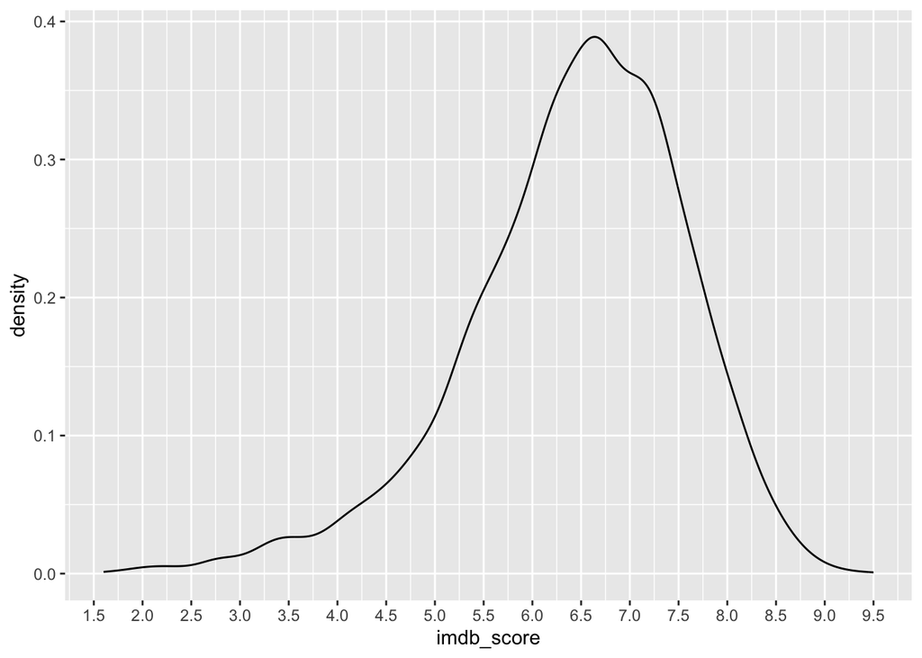

```r
ggplot(movies, aes(imdb_score)) + geom_density() + scale_x_continuous(breaks = seq(0, 10, by = 0.5))
```

### Jezik filma

```r
sort(table(movies$language), decreasing = TRUE)      # najviše na engleskom
```

```
##
##    English     French    Spanish      Hindi   Mandarin     German   Japanese
##       4583         73         40         28         24         19         17
##  Cantonese    Italian    Russian Portuguese     Korean     Arabic     Danish
##         11         11         11          8          7          5          5
##     Hebrew    Swedish      Dutch  Norwegian    Persian    Chinese     Polish
##          5          5          4          4          4          3          3
##       Thai Aboriginal       Dari  Icelandic Indonesian       None   Romanian
##          3          2          2          2          2          2          2
##       Zulu    Aramaic    Bosnian      Czech   Dzongkha   Filipino      Greek
##          2          1          1          1          1          1          1
##  Hungarian    Kannada     Kazakh       Maya  Mongolian    Panjabi  Slovenian
##          1          1          1          1          1          1          1
##    Swahili      Tamil     Telugu       Urdu Vietnamese
##          1          1          1          1          1
```

[figure not shown]

```r
movies_lan <- movies[!is.na(movies$language) , ]
movies_lan %>%
  count(language) %>%
  filter(n >= 10) %>%
  inner_join(movies, by = "language") %>%
  ggplot(aes(x = reorder(language, imdb_score, FUN = median),
             y = imdb_score)) +
  geom_boxplot() + scale_y_continuous() +
  labs(title = "IMDb score po jeziku (10+ filmova)",
       x = "Jezik",
       y = "IMDb score")
```

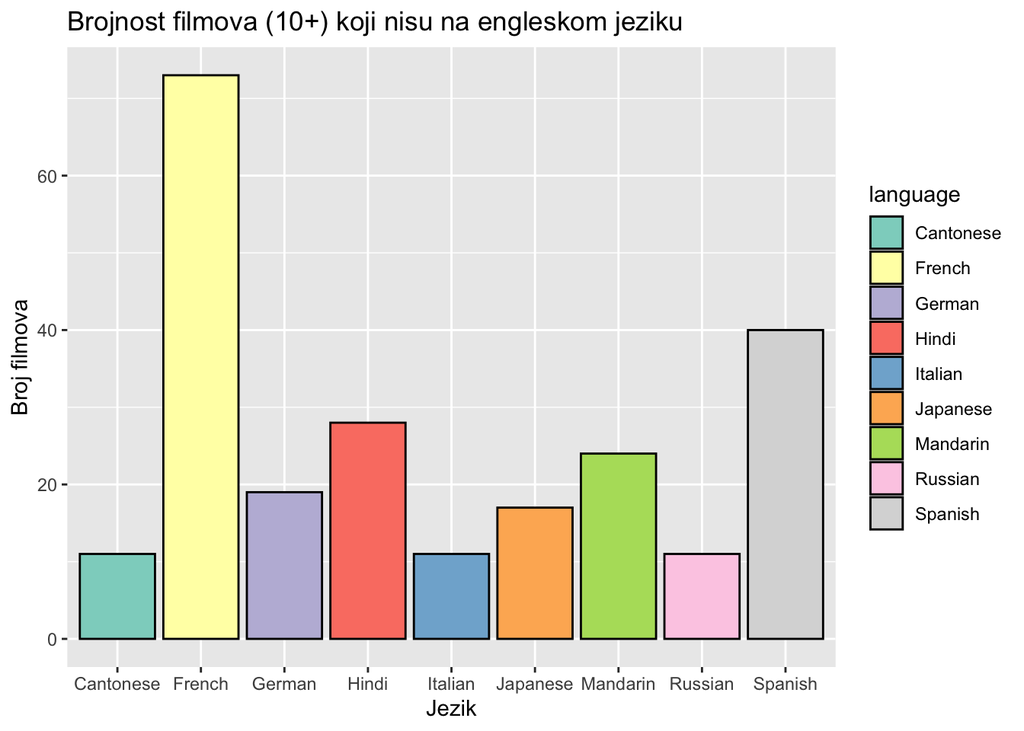

```r
lang_bez_eng <- movies[movies$language != "English", ]

movies %>%
  count(language) %>%
  filter(n >= 10, language != "English") %>%
  ggplot(aes(x = language, y = n, fill = language)) +
  geom_col( color = "black") + scale_fill_brewer(palette = "Set3") +
  labs(title = "Brojnost filmova (10+) koji nisu na engleskom jeziku",
       x = "Jezik",
       y = "Broj filmova")
```

#### 5 najbolje ocijenjenih filmova koji nisu na engleskom

```r
top5_not_english <- movies %>% filter(language != "English") %>% slice_max(order_by = imdb_score, n = 5) %>%
  dplyr::select(movie_title, language, imdb_score)

top5_not_english
```

```
##                       movie_title   language imdb_score
## 1            Dekalog                  Polish        9.1
## 2 The Good, the Bad and the Ugly     Italian        8.9
## 3           Gomorrah                 Italian        8.7
## 4                    City of God  Portuguese        8.7
## 5                  Seven Samurai    Japanese        8.7
```

Osim jezika imamo podatke i o državi u kojoj je film nastao. Normalno je očekivati američke filmove u samom vrhu zbog snažnog utjecaja Hollywooda na američku filmsku industriju. Ovaj utjecaj najbolje prikazuje brojnost američkih filmova naspram ostalih:

```r
number_usa <- movies %>% filter(country == "USA") %>% count()
number_no_usa <- movies %>% filter(country != "USA") %>% count()

number_usa
```

```
##      n
## 1 3711
```

```r
number_no_usa
```

```
##      n
## 1 1201
```

Sa otprilike trostruko većim brojem filmova, američka filmska industrija ima puno veći uzorak iz kojeg filmovi mogu biti bolje ili lošije ocijenjeni, ali pogledajmo sada tablice najbolje rangiranih američkih filmova i najbolje rangiranih filmova koji nisu iz amerike:

```r
top5_usa <- movies %>% filter(country == "USA") %>% slice_max(order_by = imdb_score, n = 5) %>%
  dplyr::select(movie_title, country, imdb_score)
top5_usa
```

```
##                 movie_title country imdb_score
## 1 The Shawshank Redemption      USA        9.3
## 2            The Godfather      USA        9.2
## 3     Kickboxer: Vengeance      USA        9.1
## 4          The Dark Knight      USA        9.0
## 5   The Godfather: Part II      USA        9.0
## 6        Fargo                  USA        9.0
```

```r
top5_no_usa <- movies %>% filter(country != "USA") %>% slice_max(order_by = imdb_score, n = 5) %>%
  dplyr::select(movie_title, country, imdb_score)
top5_no_usa
```

```
##                                          movie_title     country imdb_score
## 1                      Towering Inferno                   Canada        9.5
## 2                               Dekalog                   Poland        9.1
## 3                    The Good, the Bad and the Ugly        Italy        8.9
## 4 The Lord of the Rings: The Fellowship of the Ring  New Zealand        8.8
## 5                              Gomorrah                    Italy        8.7
## 6                                       City of God       Brazil        8.7
## 7                            Queen of the Mountains   Kyrgyzstan        8.7
## 8                                     Seven Samurai        Japan        8.7
```

Zanimljivo je uočiti da je unatoč malom broju filmova, ostatak svijeta proizveo jako dobro ocijenjene filmove .

### Filmski budžet

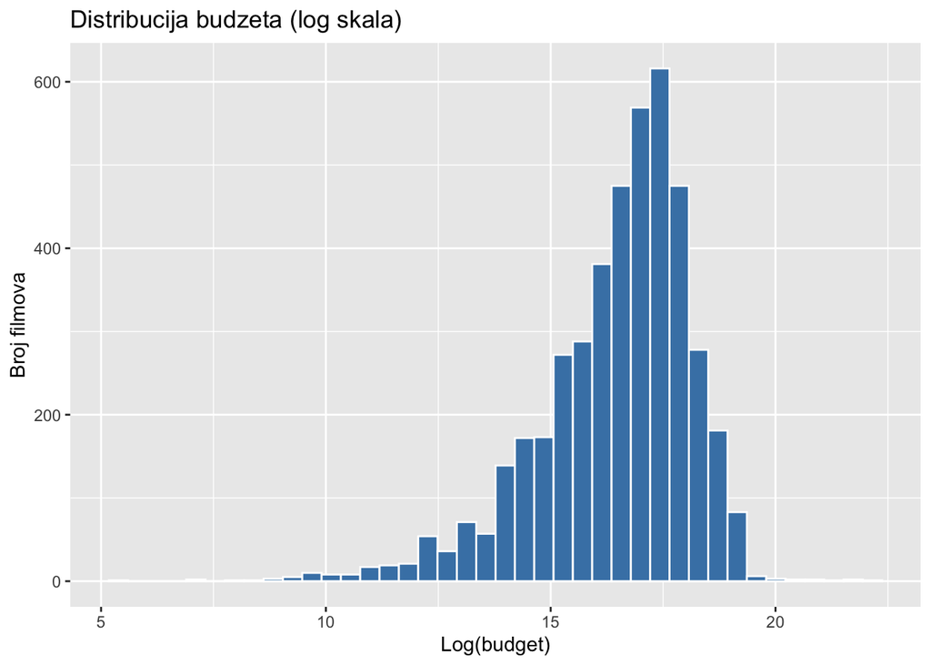

```r
movies_budget <- movies[!is.na(movies$budget),]
ggplot(movies_budget, aes(x = log(budget + 1))) +
  geom_histogram(bins = 40, fill = "steelblue", color = "white") +
  labs(title = "Distribucija budzeta (log skala)", x = "Log(budget)", y = "Broj filmova")
```

```r
summary(movies_budget$budget)
```

```
##      Min.   1st Qu.    Median      Mean   3rd Qu.      Max.
## 2.180e+02 6.000e+06 1.980e+07 3.654e+07 4.300e+07 4.200e+09
```

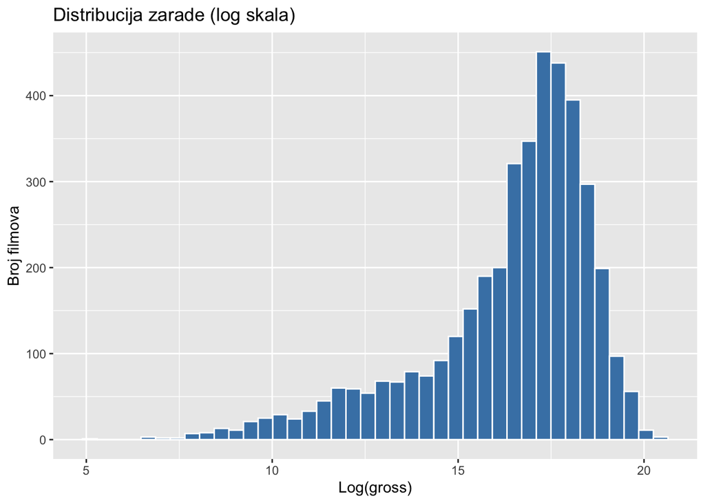

```r
movies_gross <- movies[!is.na(movies$gross),]
ggplot(movies_gross, aes(x = log(gross + 1))) +
  geom_histogram(bins = 40, fill = "steelblue", color = "white") +
  labs(title = "Distribucija zarade (log skala)",
       x = "Log(gross)",
       y = "Broj filmova")
```

```r
summary(movies_gross$gross)
```

```
##      Min.   1st Qu.    Median      Mean   3rd Qu.      Max.
##       162   5019656  25043962  47644515  61108413 760505847
```

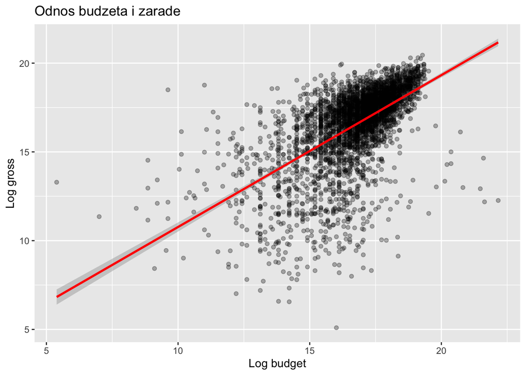

```r
movies_money <- movies_gross[!is.na(movies_gross$budget),]
ggplot(movies_money, aes(x = log(budget + 1), y = log(gross + 1))) +
  geom_point(alpha = 0.3) +
  geom_smooth(method = "lm", color = "red") +
  labs(title = "Odnos budzeta i zarade",
       x = "Log budget",
       y = "Log gross")
```

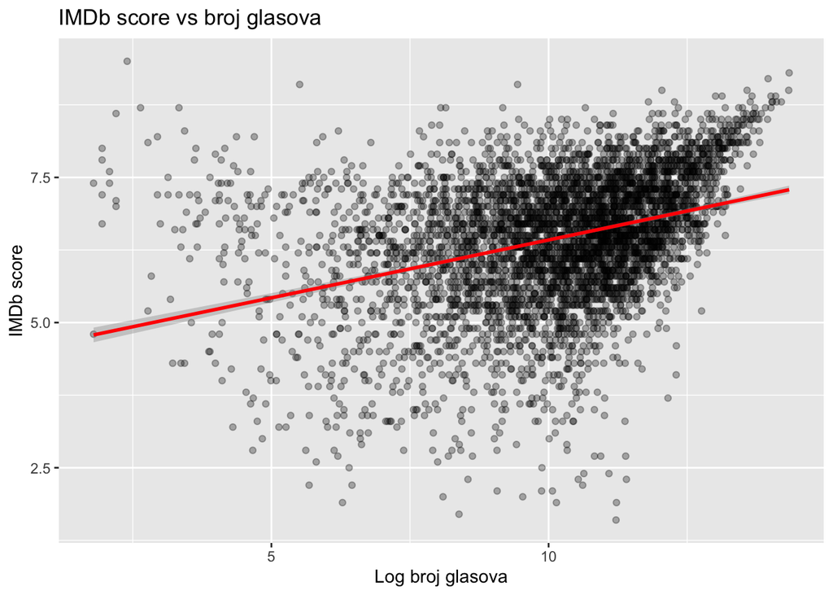

```r
movies_glasovi <- movies[!is.na(movies$num_voted_users),]
ggplot(movies_glasovi, aes(x = log(num_voted_users + 1), y = imdb_score)) +
  geom_point(alpha = 0.3) +
  geom_smooth(method = "lm", color = "red") +
  labs(title = "IMDb score vs broj glasova",
       x = "Log broj glasova",
       y = "IMDb score")
```

[figure not shown]

```r
koef_korelacija_prije <- cor(movies_glasovi$num_voted_users, movies_glasovi$imdb_score)

movies_glasovi <- movies_glasovi[movies_glasovi$num_voted_users > 100000,]
ggplot(movies_glasovi, aes(x = log(num_voted_users + 1), y = imdb_score)) +
  geom_point(alpha = 0.3) +
  geom_smooth(formula = y ~ x, method = "lm", color = "red") +
  labs(title = "IMDb score vs broj glasova",
       x = "Log broj glasova",
       y = "IMDb score")
```

```r
koef_korelacija_poslije <- cor(movies_glasovi$num_voted_users, movies_glasovi$imdb_score)

koef_korelacija_prije
```

```
## [1] 0.4123669
```

```r
koef_korelacija_poslije
```

```
## [1] 0.5305801
```

[figure not shown]

```r
movies_trend <- movies[!is.na(movies$title_year), ]
ggplot(movies_trend, aes(x = title_year, y = imdb_score)) +
  geom_point(alpha = 0.2) +
  geom_smooth(method = "loess", color = "blue") +
  labs(title = "Trend IMDb ratinga kroz godine",
       x = "Godina",
       y = "IMDb score")
```

[figure not shown]

```r
movies_trend <- movies_trend %>% group_by(title_year) %>% summarise(median_rating = median(imdb_score))
ggplot(movies_trend, aes(x = title_year, y = median_rating)) + geom_point() + geom_smooth(method = "loess") + geom_line(group = 1) +
  labs(title = "Medijan IMDb ratinga kroz godine",
       x = "Godina",
       y = "Medijan IMDb score")
```

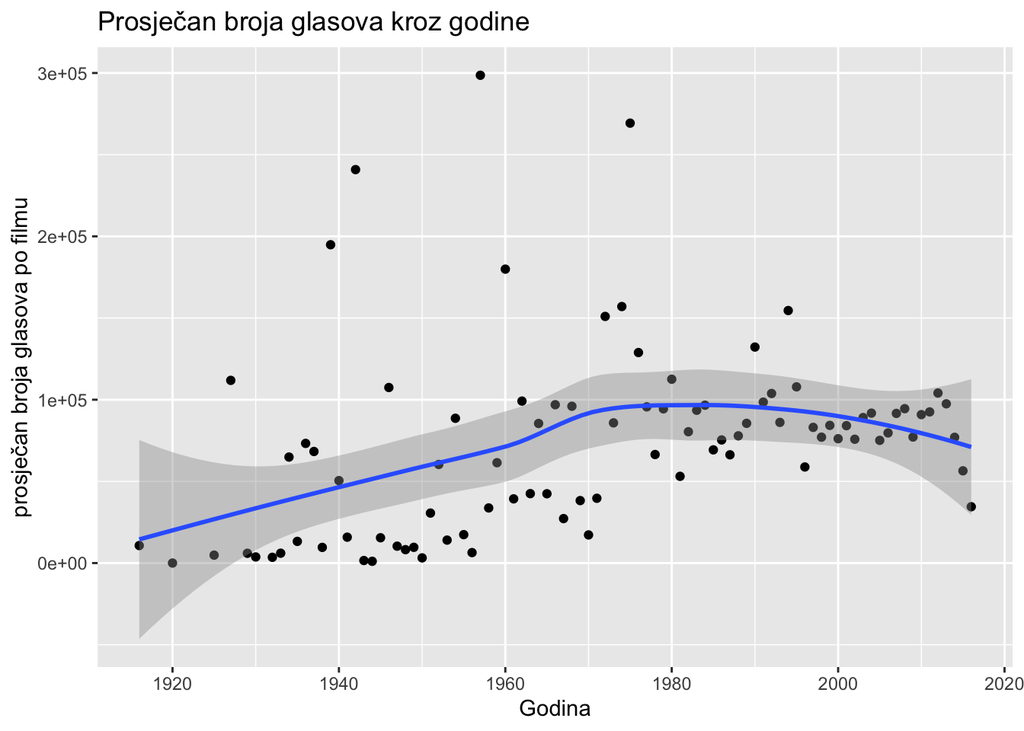

```r
movies_trend2 <- movies[!is.na(movies$num_voted_users) & !is.na(movies$title_year), ] %>% group_by(title_year) %>% summarise(avg_votes = (mean(num_voted_users)))
ggplot(movies_trend2, aes(x = title_year, y = (avg_votes))) + geom_point() + geom_smooth(method = "loess")  +
  labs(title = "Prosječan broja glasova kroz godine",
       x = "Godina",
       y = "prosječan broja glasova po filmu")
```

### ispisi par filmova za 1942, 1957, 1975

```r
movies_trend3 <- movies[!is.na(movies$movie_title),] %>% group_by(title_year) %>% arrange(desc(imdb_score))
movies_1942 <- movies_trend3[movies_trend3$title_year == 1942, ] %>% slice_head(n = 3)
movies_1957 <- movies_trend3[movies_trend3$title_year == 1957, ] %>% slice_head(n = 3)
movies_1975 <- movies_trend3[movies_trend3$title_year == 1975, ] %>% slice_head(n = 3)

cat("Najbolje ocjenjeni filmovi iz 1942. godine: ",
paste(movies_1942$movie_title[!is.na(movies_1942$movie_title)], collapse = ","), "\n")
```

```
## Najbolje ocjenjeni filmovi iz 1942. godine:  Casablanca ,Bambi
```

```r
cat("Najbolje ocjenjeni filmovi iz 1957. godine: ",
    paste(movies_1957$movie_title[!is.na(movies_1957$movie_title)], collapse = ", "),
     "\n")
```

```
## Najbolje ocjenjeni filmovi iz 1957. godine:  12 Angry Men , The Bridge on the River Kwai
```

```r
cat("Najbolje ocjenjeni filmovi iz 1975. godine: ",
    paste(movies_1975$movie_title[!is.na(movies_1975$movie_title)], collapse = ", "),
     "\n")
```

```
## Najbolje ocjenjeni filmovi iz 1975. godine:  One Flew Over the Cuckoo's Nest , Monty Python and the Holy Grail , Barry Lyndon
```

[figure not shown]

```r
genre_stats <- movies %>%
  separate_rows(genres, sep = "\\|") %>%
  group_by(genres) %>%
  summarise(
    avg_rating = mean(imdb_score, na.rm = TRUE),
    n = n()
  ) %>%
  filter(n >= 100) %>%  # da makneš rijetke žanrove
  arrange(desc(avg_rating)) %>% # sortiraj po ratingu
  slice_head(n = 8)

ggplot(genre_stats,
       aes(x = reorder(genres, avg_rating), y = avg_rating, fill = genres)) +
  geom_col() + scale_fill_brewer(palette = "Paired") +
  labs(title = "Prosječan IMDb rating po žanru",
       x = "Žanr",
       y = "Prosječan rating")
```

```r
#library(RColorBrewer)
#display.brewer.all()
```

## PITANJA:

# prosječan IMDB_rating i zarada prema žanru

# usporedba ratinga kritičara i publike

# graf godina - rating -> trend?

# duration - broj reviews usera

## Omjer budgeta i ratinga

[figure not shown]

```r
ggplot(movies_budget, aes(x = log(budget + 1), y = imdb_score)) +
  geom_point(alpha = 0.3) +
  geom_smooth(formula = y ~ x, method = "lm", color = "red") +
  labs(title = "Budzet vs IMDb rating",
       x = "Log budget",
       y = "IMDb score")
```

```r
cor(movies_budget$budget, movies_budget$imdb_score)
```

```
## [1] 0.05094991
```

## Omjer zarade i ratinga

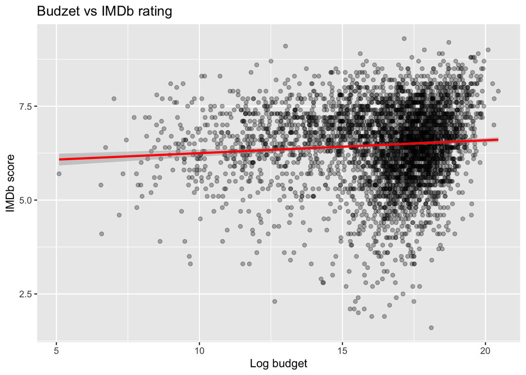

```r
ggplot(movies_gross, aes(x = log(gross + 1), y = imdb_score)) +
  geom_point(alpha = 0.3) +
  geom_smooth(formula = y ~ x, method = "lm", color = "red") +
  labs(title = "Budzet vs IMDb rating",
       x = "Log budget",
       y = "IMDb score")
```

```r
cor(movies_gross$gross, movies_gross$imdb_score)
```

```
## [1] 0.1999136
```

## Linearni model ratinga

Pokušajmo sada odrediti linearnu funkciju koja najbolje opisuje IMDb rating.